# Analysis of Twitch streamer success

## Twitch Data Set

- **source:** [Kaggle Twitch Data Set](https://www.kaggle.com/aayushmishra1512/twitchdata/version/3)
- The data set consists of the top 1000 streamers on twitch and their statistics barring actual income
- **Question:** Does stream time (*as in time that a streamer is online streaming*) have a significant effect on the amount of watch time that a streamer gets?

[figure not shown]

## Question Methodology

- The reason this question is important is because it could show that if streamers put in the time streaming a lot and consistently then they could grow.
- If this is not the case, what other feature is effecting the growth and size of channels on the top 1000?
- Is it *pure luck* or a *meritocracy* for those on Twitch?

## Top 10 chart

Top 10 Twitch Streamers and Stream Time

| Channel | Watch time(Minutes) | Stream time(minutes) |
| --- | --- | --- |
| xQcOW | 6196161750 | 215250 |
| summit1g | 6091677300 | 211845 |
| Gaules | 5644590915 | 515280 |
| ESL_CSGO | 3970318140 | 517740 |
| Tfue | 3671000070 | 123660 |

## Top 10 (cont.)

Top 10 Twitch Streamers and Stream Time

| Channel | Watch time(Minutes) | Stream time(minutes) |
| --- | --- | --- |
| Asmongold | 3668799075 | 82260 |
| NICKMERCS | 3360675195 | 136275 |
| Fextralife | 3301867485 | 147885 |
| loltyler1 | 2928356940 | 122490 |
| Anomaly | 2865429915 | 92880 |

## Top 10 watch time

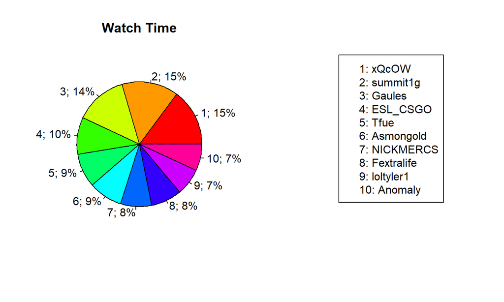

## Top 10 time streamed

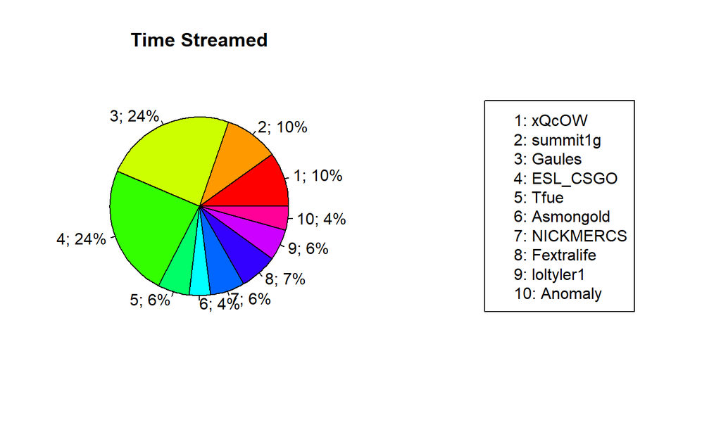

## Distribution of watch time among top 1k

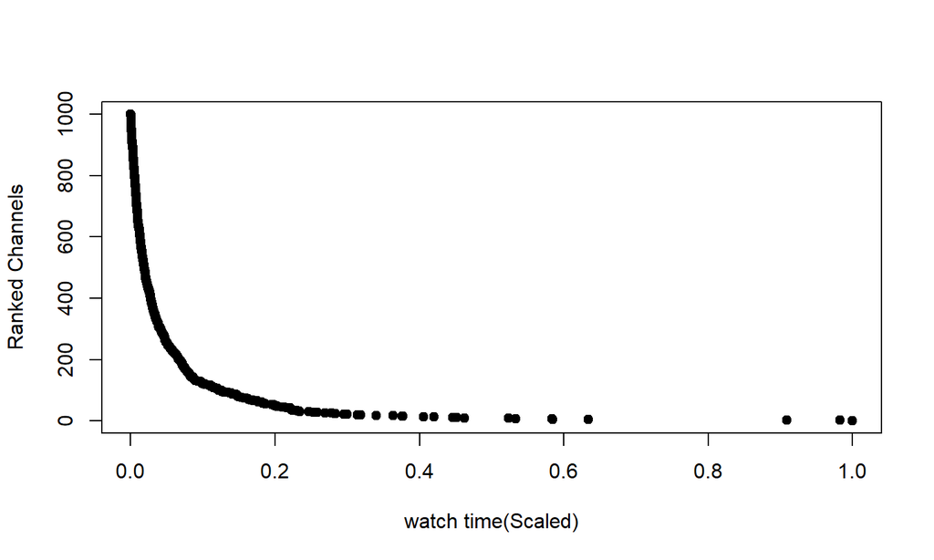

## Differences in the top 1k

- The previous chart showed the major differences between watch time of the top 1k channels, but to put it in to better perspective allow us to look at #1 and #1000
- xQcOW (#1) has 51 times the amount of watch time that Remx (#1000) has
- But, he only has 2 times the stream time

## Distribution of stream time among top 1k

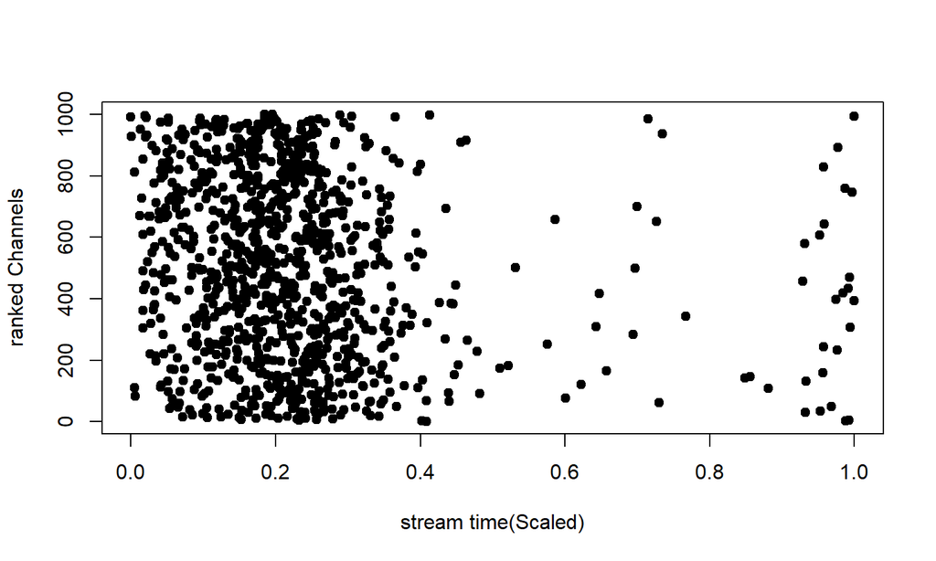

## Differences in the top 1k (cont)

- This new chart of stream times shows that there is a *bit* of a trend towards larger streamers streaming for longer but it’s not very significant and as you can see below its not a good metric for predicting success

[figure not shown]

## top 5 ratios

- In this column of watch time vs stream time its clear that the ratio varies wildly without any extra visualizations

| Channel | ratio |
| --- | --- |
| xQcOW | 28785.885 |
| summit1g | 28755.351 |
| Gaules | 10954.415 |
| ESL_CSGO | 7668.556 |
| Tfue | 29686.237 |

## In conclusion

- There is no significant correlation between watch time and time streamed
- Does that mean that the success of streamers is completely up to luck?
- No, but it could. The watch time seems to be a function of avg viewers and time streamed and that combination of the two varies from channel to channel
- each channel is different some are independent streamers that may stream a little but garner a large audience others are large organizations that can afford to stream all the time
- I think that if anything a more important question to ask would be if watch time should be considered a metric of success when something like income generated could be more tangible and involves amount of ads streamers run as well the income generated from stream time and large audiences
- so, if I could get data for income next time I would have to pull add frequency as well as these watch times to see if they correlate